# Regression Analysis: Motor Trend

Marcio Gualtieri

# Required Packages

You might need to install and load the following packages if you don’t already have them:

```r
suppressMessages(library(xtable))                            # Pretty printing dataframes
suppressMessages(library(ggplot2))                           # Plotting
suppressMessages(library(gridExtra, warn.conflicts = FALSE))
suppressMessages(library(reshape2))                          # Transforming Data Frames
```

# Overview

You work for Motor Trend, a magazine about the automobile industry. Looking at a data set of a collection of cars, they are interested in exploring the relationship between a set of variables and miles per gallon (MPG) (outcome). They are particularly interested in the following two questions:

- Is an automatic or manual transmission better for MPG?
- Quantify the MPG difference between automatic and manual transmissions.

# Data Loading

Our data-set consists of `mtcars`, which comes with R. You will find more information about it [here](https://stat.ethz.ch/R-manual/R-devel/library/datasets/html/mtcars.html).

```r
data(mtcars)
```

# Exploratory Data Analysis

## Variables

R’s [documentation for this data-set](https://stat.ethz.ch/R-manual/R-devel/library/datasets/html/mtcars.htm) provides some of the following information:

| Variable | Description | Comment |
| --- | --- | --- |
| mpg | Miles per (US) gallon |  |
| cyl | Number of cylinders |  |
| disp | Displacement (cu.in.) | Volume displaced when all engine’s pistons perform a single move. Greater volume, greater engine. |
| hp | Gross horsepower |  |
| drat | Rear axle ratio | Greater ratio, greater engine’s RPM required to keep the same speed. |
| wt | Weight (1000 lbs) |  |
| qsec | 1/4 mile time | Least amount of time in seconds required to cover 1/4 of a mile. More powerful engine, least qsec. |
| vs | V/S (0 = V engine, 1 = Straight engine) | Pistons configuration in the engine, i.e., mounted in a “V” shape or straight. |
| am | Transmission (0 = automatic, 1 = manual) |  |
| gear | Number of forward gears | In general manual transmission have more gears, but automatic has been catching up in recent years. |
| carb | Number of carburetors | Cars these days use fuel injection, thus this makes me think this data-set is a bit old. |

## Data Types

You may inspect the schema by executiong the following command:

```r
str(mtcars)
```

They are all numbers, but some should be categories. I will map them (`am` and `vs`,both categorical) to factors for easier reading:

```r
mtcars$am <- ifelse(mtcars$am == 0, "Automatic", "Manual")
mtcars$am <- as.factor(mtcars$am)
mtcars$vs <- ifelse(mtcars$vs == 0, "V-Engine", "Straight Engine")
mtcars$vs <- as.factor(mtcars$vs)
```

## Sampling Data

```r
render_table <- function(data) {
  options(xtable.comment = FALSE)
  print(xtable(data))
}
sample_data_frame <- function(data, size) {
  sample_index <- sample(1:nrow(data), size)
  return(data[sample_index, ])
}
render_table(sample_data_frame(mtcars, 6))
```

[output not shown]

## Data Visualization

### Scatter Plot Matrix

You may plot it by executing the following command:

```r
pairs(mtcars, panel = panel.smooth, main = "Motor Trend", col = "light blue")
```

But I find correlation heat maps more compact and easier to read.

### Correlation Heat Map

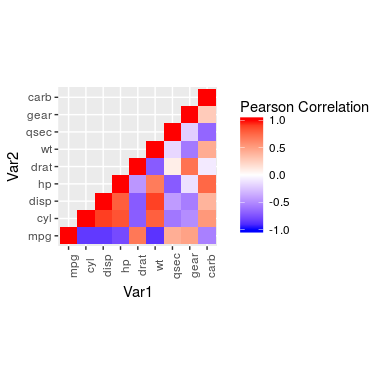

```r
correlation_matrix <- function(data) {
  numeric_data <- data[, sapply(data,is.numeric)]
  matrix <- round(cor(numeric_data), 2)
  matrix[upper.tri(matrix)] <- NA
  matrix <- melt(matrix, na.rm = TRUE)
  return(matrix)
}
correlation_heat_map <- function(data) {
  matrix <- correlation_matrix(data)
  ggplot(data = matrix, aes(x = Var1, y = Var2, fill = value)) +
  geom_tile() +
  scale_fill_gradient2(low = "blue", high = "red", mid = "white", midpoint = 0, limit = c(-1, 1), name="Pearson Correlation") +
  theme(axis.text.x = element_text(angle = 90)) +
  coord_fixed()
}
correlation_heat_map(mtcars)
```

The potential predictors for MPG seem correlated among themselves to some degree, with a few exceptions:

- `gear` seems weakly correlated to `hp`.
- `drat` seems weakly correlated to `qsec` or `carb`.
- `wt` seems weakly correlated to `qsec`.

### Box Plots

Here are some box plots for the data:

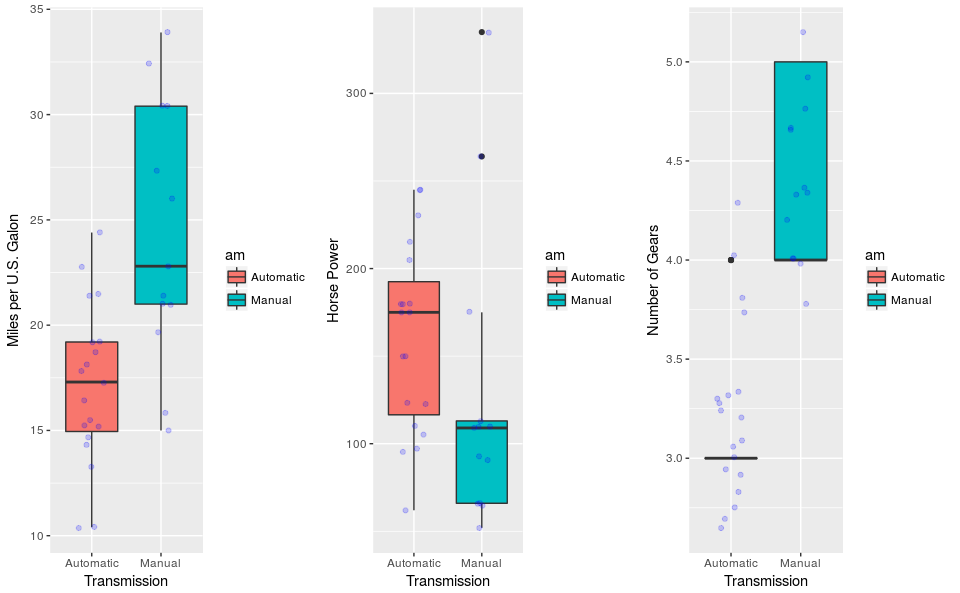

```r
box_plot <- function(data, y_column, x_column, x_title, y_title) {
  ggplot(data, aes_string(y = y_column, x = x_column)) +
  geom_boxplot(aes_string(fill = x_column)) +
  geom_point(position = position_jitter(width = 0.2), color = "blue", alpha = 0.2) +
  xlab(x_title) +
  ylab(y_title)
}
mpg_box <- box_plot(mtcars, "mpg", "am", "Transmission", "Miles per U.S. Galon")
hp_box <- box_plot(mtcars, "hp", "am", "Transmission", "Horse Power")
gear_box <- box_plot(mtcars, "gear", "am", "Transmission", "Number of Gears")
grid.arrange(mpg_box, hp_box, gear_box, ncol = 3)
```

- The vehicles with automatic transmission in the data-set seem to have greater horsepower, which correlates to less fuel efficiency.
- The vehicles with manual transmission have a greater number of gears.

# Predictors Analysis

## Linear Models

Let’s try different models and look at their p-values to check their effect in the response (`mpg`):

```r
summary(lm(mpg ~ . - 1, data = mtcars))$coef
```

```
                     Estimate  Std. Error    t value   Pr(>|t|)
cyl               -0.11144048  1.04502336 -0.1066392 0.91608738
disp               0.01333524  0.01785750  0.7467585 0.46348865
hp                -0.02148212  0.02176858 -0.9868407 0.33495531
drat               0.78711097  1.63537307  0.4813036 0.63527790
wt                -3.71530393  1.89441430 -1.9611887 0.06325215
qsec               0.82104075  0.73084480  1.1234133 0.27394127
vsStraight Engine 12.62113697 19.02841514  0.6632784 0.51436802
vsV-Engine        12.30337416 18.71788443  0.6573058 0.51812440
amManual           2.52022689  2.05665055  1.2254035 0.23398971
gear               0.65541302  1.49325996  0.4389142 0.66520643
carb              -0.19941925  0.82875250 -0.2406258 0.81217871
```

```r
summary(lm(mpg ~ cyl + carb + disp + hp - 1, data = mtcars))$coef
```

```
        Estimate Std. Error    t value     Pr(>|t|)
cyl   8.05102716 1.08883280  7.3941813 4.722706e-08
carb -1.24236370 1.57941786 -0.7865960 4.381256e-01
disp -0.10883620 0.02604514 -4.1787525 2.597453e-04
hp   -0.01769896 0.05625941 -0.3145955 7.554011e-01
```

The null hypothesis that $hp = 0$ is accepted due to its p-value. Using common sense and domain knowledge (refer to the `Correlation Heat Map` section), we may come up with the following model:

```r
fit_common_sense_with_gear <- lm(mpg ~ gear + hp + wt + drat, data = mtcars)
```

But given that the questions wee need to answer are related to transmission, let’s replace `gear` with `am`, even though we know that `gear` is actually directly correlated to `mpg` and `am` is directly correlated to `gear`:

```r
fit_common_sense_with_am <- lm(mpg ~ am + hp + wt + drat, data = mtcars)
summary(fit_common_sense_with_am)
```

```
Call:
lm(formula = mpg ~ am + hp + wt + drat, data = mtcars)

Residuals:
    Min      1Q  Median      3Q     Max
-3.2882 -1.7531 -0.6827  1.1691  5.5211

Coefficients:
             Estimate Std. Error t value Pr(>|t|)
(Intercept) 30.027077   6.185177   4.855  4.5e-05 ***
amManual     1.578521   1.559281   1.012 0.320363
hp          -0.036373   0.009814  -3.706 0.000958 ***
wt          -2.726092   0.937791  -2.907 0.007209 **
drat         0.981018   1.377101   0.712 0.482341
---
Signif. codes:  0 ‘***’ 0.001 ‘**’ 0.01 ‘*’ 0.05 ‘.’ 0.1 ‘ ’ 1

Residual standard error: 2.56 on 27 degrees of freedom
Multiple R-squared:  0.8428,    Adjusted R-squared:  0.8196
F-statistic:  36.2 on 4 and 27 DF,  p-value: 1.75e-10
```

We may automate this process using [step](https://stat.ethz.ch/R-manual/R-devel/library/stats/html/step.html) as follows:

```r
fit_all <- lm(mpg ~ ., data = mtcars)
fit_best <- step(fit_all, direction = "both", trace = FALSE)
summary(fit_best)
```

```
Call:
lm(formula = mpg ~ wt + qsec + am, data = mtcars)

Residuals:
    Min      1Q  Median      3Q     Max
-3.4811 -1.5555 -0.7257  1.4110  4.6610

Coefficients:
            Estimate Std. Error t value Pr(>|t|)
(Intercept)   9.6178     6.9596   1.382 0.177915
wt           -3.9165     0.7112  -5.507 6.95e-06 ***
qsec          1.2259     0.2887   4.247 0.000216 ***
amManual      2.9358     1.4109   2.081 0.046716 *
---
Signif. codes:  0 ‘***’ 0.001 ‘**’ 0.01 ‘*’ 0.05 ‘.’ 0.1 ‘ ’ 1

Residual standard error: 2.459 on 28 degrees of freedom
Multiple R-squared:  0.8497,    Adjusted R-squared:  0.8336
F-statistic: 52.75 on 3 and 28 DF,  p-value: 1.21e-11
```

The “common sense” models did slightly worst in the residuals squared, but they are easier to understand.